# Big Mart Sales Prediction

The data scientists at BigMart have collected sales data for 1559 products across 10 stores in different cities for the year 2013. Now each product has certain attributes that sets it apart from other products. Same is the case with each store.

The aim is to build a predictive model to find out the sales of each product at a particular store so that it would help the decision makers at BigMart to find out the properties of any product or store, which play a key role in increasing the overall sales.

## Loading Packages

```r
library(tidyverse)
library(readr)
library(gridExtra)
library(randomForest)
library(caret)
library(mlr)
library(knitr)
```

## Importing Data

```r
Train <- read_csv("Train.csv")
Test <- read_csv("Test.csv")
```

### Understanding Dataset

```r
# Dimension of Data
dim(Train)
```

```
[1] 8523   12
```

```r
dim(Test)
```

```
[1] 5681   11
```

```r
# Structure of Data
str(Train)
```

```
Classes spec_tbl_df, tbl_df, tbl and 'data.frame':    8523 obs. of  12 variables:
 $ Item_Identifier          : chr  "FDA15" "DRC01" "FDN15" "FDX07" ...
 $ Item_Weight              : num  9.3 5.92 17.5 19.2 8.93 ...
 $ Item_Fat_Content         : chr  "Low Fat" "Regular" "Low Fat" "Regular" ...
 $ Item_Visibility          : num  0.016 0.0193 0.0168 0 0 ...
 $ Item_Type                : chr  "Dairy" "Soft Drinks" "Meat" "Fruits and Vegetables" ...
 $ Item_MRP                 : num  249.8 48.3 141.6 182.1 53.9 ...
 $ Outlet_Identifier        : chr  "OUT049" "OUT018" "OUT049" "OUT010" ...
 $ Outlet_Establishment_Year: num  1999 2009 1999 1998 1987 ...
 $ Outlet_Size              : chr  "Medium" "Medium" "Medium" NA ...
 $ Outlet_Location_Type     : chr  "Tier 1" "Tier 3" "Tier 1" "Tier 3" ...
 $ Outlet_Type              : chr  "Supermarket Type1" "Supermarket Type2" "Supermarket Type1" "Grocery Store" ...
 $ Item_Outlet_Sales        : num  3735 443 2097 732 995 ...
 - attr(*, "spec")=
  .. cols(
  ..   Item_Identifier = col_character(),
  ..   Item_Weight = col_double(),
  ..   Item_Fat_Content = col_character(),
  ..   Item_Visibility = col_double(),
  ..   Item_Type = col_character(),
  ..   Item_MRP = col_double(),
  ..   Outlet_Identifier = col_character(),
  ..   Outlet_Establishment_Year = col_double(),
  ..   Outlet_Size = col_character(),
  ..   Outlet_Location_Type = col_character(),
  ..   Outlet_Type = col_character(),
  ..   Item_Outlet_Sales = col_double()
  .. )
```

```r
str(Test)
```

```
Classes spec_tbl_df, tbl_df, tbl and 'data.frame':    5681 obs. of  11 variables:
 $ Item_Identifier          : chr  "FDW58" "FDW14" "NCN55" "FDQ58" ...
 $ Item_Weight              : num  20.75 8.3 14.6 7.32 NA ...
 $ Item_Fat_Content         : chr  "Low Fat" "reg" "Low Fat" "Low Fat" ...
 $ Item_Visibility          : num  0.00756 0.03843 0.09957 0.01539 0.1186 ...
 $ Item_Type                : chr  "Snack Foods" "Dairy" "Others" "Snack Foods" ...
 $ Item_MRP                 : num  107.9 87.3 241.8 155 234.2 ...
 $ Outlet_Identifier        : chr  "OUT049" "OUT017" "OUT010" "OUT017" ...
 $ Outlet_Establishment_Year: num  1999 2007 1998 2007 1985 ...
 $ Outlet_Size              : chr  "Medium" NA NA NA ...
 $ Outlet_Location_Type     : chr  "Tier 1" "Tier 2" "Tier 3" "Tier 2" ...
 $ Outlet_Type              : chr  "Supermarket Type1" "Supermarket Type1" "Grocery Store" "Supermarket Type1" ...
 - attr(*, "spec")=
  .. cols(
  ..   Item_Identifier = col_character(),
  ..   Item_Weight = col_double(),
  ..   Item_Fat_Content = col_character(),
  ..   Item_Visibility = col_double(),
  ..   Item_Type = col_character(),
  ..   Item_MRP = col_double(),
  ..   Outlet_Identifier = col_character(),
  ..   Outlet_Establishment_Year = col_double(),
  ..   Outlet_Size = col_character(),
  ..   Outlet_Location_Type = col_character(),
  ..   Outlet_Type = col_character()
  .. )
```

### Combining Test and Train Dataset

```r
Test$Item_Outlet_Sales = NA
All <- rbind(Train,Test)
str(All)
```

```
Classes spec_tbl_df, tbl_df, tbl and 'data.frame':    14204 obs. of  12 variables:
 $ Item_Identifier          : chr  "FDA15" "DRC01" "FDN15" "FDX07" ...
 $ Item_Weight              : num  9.3 5.92 17.5 19.2 8.93 ...
 $ Item_Fat_Content         : chr  "Low Fat" "Regular" "Low Fat" "Regular" ...
 $ Item_Visibility          : num  0.016 0.0193 0.0168 0 0 ...
 $ Item_Type                : chr  "Dairy" "Soft Drinks" "Meat" "Fruits and Vegetables" ...
 $ Item_MRP                 : num  249.8 48.3 141.6 182.1 53.9 ...
 $ Outlet_Identifier        : chr  "OUT049" "OUT018" "OUT049" "OUT010" ...
 $ Outlet_Establishment_Year: num  1999 2009 1999 1998 1987 ...
 $ Outlet_Size              : chr  "Medium" "Medium" "Medium" NA ...
 $ Outlet_Location_Type     : chr  "Tier 1" "Tier 3" "Tier 1" "Tier 3" ...
 $ Outlet_Type              : chr  "Supermarket Type1" "Supermarket Type2" "Supermarket Type1" "Grocery Store" ...
 $ Item_Outlet_Sales        : num  3735 443 2097 732 995 ...
 - attr(*, "spec")=
  .. cols(
  ..   Item_Identifier = col_character(),
  ..   Item_Weight = col_double(),
  ..   Item_Fat_Content = col_character(),
  ..   Item_Visibility = col_double(),
  ..   Item_Type = col_character(),
  ..   Item_MRP = col_double(),
  ..   Outlet_Identifier = col_character(),
  ..   Outlet_Establishment_Year = col_double(),
  ..   Outlet_Size = col_character(),
  ..   Outlet_Location_Type = col_character(),
  ..   Outlet_Type = col_character(),
  ..   Item_Outlet_Sales = col_double()
  .. )
```

## **Data Visualization**

### Target Variable

Since our target variable is continuous, we can visualise it by plotting its histogram.

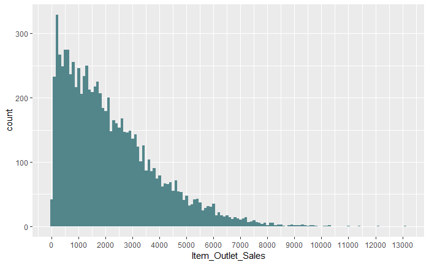

```r
ggplot(Train, aes(Item_Outlet_Sales)) +
  geom_histogram(binwidth = 100, fill = "cadetblue4") +
    scale_x_continuous(breaks = seq(0,14000, by =1000))
```

As you can see, it is a right skewd variable and would need some data transformation to treat its skewness.

## Independent Variables (Continuous)

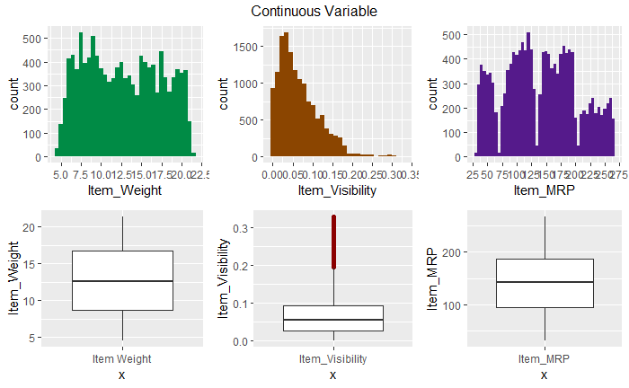

```r
p11 <-ggplot(All, aes(Item_Weight)) +
      geom_histogram( fill = "springgreen4", na.rm = TRUE,binwidth = 0.5)+
      scale_x_continuous(breaks = seq(0,25, by =2.5))
p12 <-ggplot(All, aes(Item_Visibility)) +
      geom_histogram( fill = "darkorange4", na.rm = TRUE)+
      scale_x_continuous(breaks = seq(0,0.5, by =0.05))
p13 <-ggplot(All, aes(Item_MRP)) +
      geom_histogram( fill = "purple4", na.rm = TRUE,binwidth = 5)+
      scale_x_continuous(breaks = seq(0,300, by =25))
p31 <- ggplot(All, aes(x= 'Item Weight',y=Item_Weight)) +
          geom_boxplot(outlier.colour = "red4")
p32 <- ggplot(All, aes(x= 'Item_Visibility',y=Item_Visibility)) +
          geom_boxplot(outlier.colour = "red4")
p33 <- ggplot(All, aes(x= 'Item_MRP',y=Item_MRP)) +
          geom_boxplot(outlier.colour = "red4")
grid.arrange(
          p11,p12,p13,p31,p32,p33,nrow = 2,
          top = "Continuous Variable")
```

- Observations
- Item_MRP has clear cuts, i.e we can see 4 different distributions
- Item_Visibility is right-skewed and should be transformed
- No pattern in Item_Weight

### Independent Variables (Categorical)

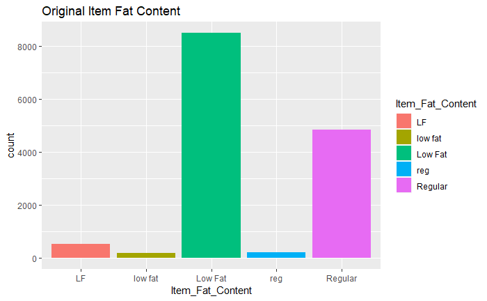

```r
ggplot(All, aes(Item_Fat_Content,fill = Item_Fat_Content)) +
  geom_bar(na.rm = TRUE) + ggtitle("Original Item Fat Content")
```

```r
# Convert factor in character [Item_Fat_Content]
All$Item_Fat_Content <- as_factor(All$Item_Fat_Content)
# check levels
levels(All$Item_Fat_Content)
```

```
[1] "Low Fat" "Regular" "low fat" "LF"      "reg"
```

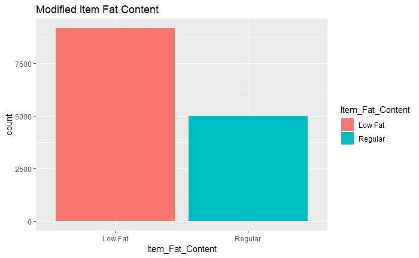

```r
# replace LF,low fat with Low Fat
levels( All$Item_Fat_Content)[3:4] <- "Low Fat"
# replace ref with Regular
levels( All$Item_Fat_Content )[3] <- "Regular"
ggplot(All, aes(Item_Fat_Content,fill = Item_Fat_Content)) +
  geom_bar(na.rm = TRUE) + ggtitle("Modified Item Fat Content")
```

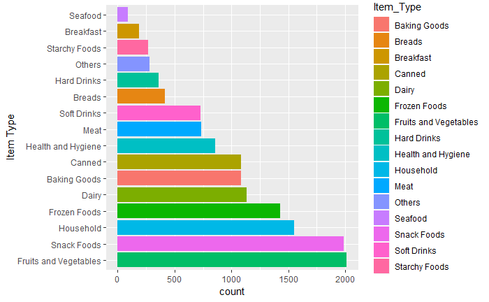

```r
ggplot(All, aes(fct_infreq(Item_Type),fill = Item_Type)) +
  geom_bar( na.rm = TRUE)+ xlab("Item Type") +
    coord_flip()
```

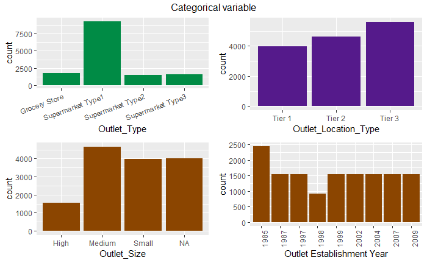

```r
p21 <- ggplot(All, aes(Outlet_Type)) +
        geom_bar(fill = "springgreen4", na.rm = TRUE) +
          theme(axis.text.x = element_text(angle = 20, hjust = 1))
p22 <- ggplot(All, aes(Outlet_Location_Type )) +
        geom_bar(fill = "purple4", na.rm = TRUE)
p23 <- ggplot(All, aes(Outlet_Size)) +
        geom_bar(fill = "darkorange4", na.rm = TRUE)
p24 <- ggplot(All, aes(factor(Outlet_Establishment_Year))) +
        geom_bar(fill = "darkorange4", na.rm = TRUE) +
          theme(axis.text.x = element_text(angle = 90, hjust = 1)) +
            xlab("Outlet Establishment Year")
grid.arrange(p21,p22,p23,p24, nrow = 2,
        top = "Categorical variable")
```

- Obsevations
- People likes to go Supermarket Type I the most
- Large no. of missing values in Outlet Size

### **Bivariate Analysis**

Extracting train data from the All Data

```r
Train = All[1:nrow(Train),]
```

### Target Variable vs Independent Continuous Variables

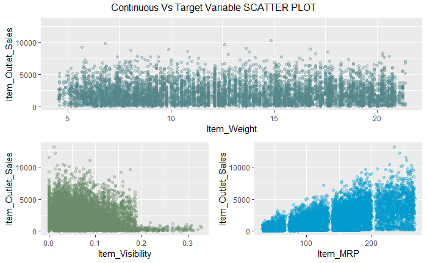

```r
# Continuous Vs Target Variable
p61 <- ggplot(Train, aes(Item_Weight,Item_Outlet_Sales))+
        geom_point(colour = 'cadetblue4',alpha=0.3)

p62 <- ggplot(Train, aes(Item_Visibility,Item_Outlet_Sales))+
        geom_point(colour = 'darkseagreen4',alpha=0.3)
p63 <- ggplot(Train, aes(Item_MRP,Item_Outlet_Sales))+
        geom_point(colour = 'deepskyblue3',alpha=0.3)
grid.arrange(
          p61,
          arrangeGrob(p62,p63,ncol = 2),
          nrow = 2,
          top = "Continuous Vs Target Variable SCATTER PLOT")
```

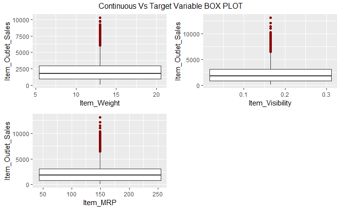

```r
p71 <- ggplot(All, aes(x=Item_Weight,y=Item_Outlet_Sales)) +
          geom_boxplot(outlier.colour = "red4")
p72 <- ggplot(All, aes(x= Item_Visibility,y=Item_Outlet_Sales)) +
          geom_boxplot(outlier.colour = "red4")
p73 <- ggplot(All, aes(x= Item_MRP,y=Item_Outlet_Sales)) +
          geom_boxplot(outlier.colour = "red4")
grid.arrange(
          p71,p72,p73,nrow = 2,
          top = "Continuous Vs Target Variable BOX PLOT")
```

- Observations
- **Item_Outlet_Sales** is spread well across the entire range of the **Item_Weight** without any obvious pattern.
- In **Item_Visibility vs Item_Outlet_Sales**, there is a string of points at **Item_Visibility = 0.0** which seems strange as item visibility cannot be completely zero.Also we can see the sudden decrease in of Products as Item visibility Increases.
- In **Item_MRP vs Item_Outlet_Sales**, we can clearly see 4 segments of prices
- Extreme values are encounted in all Box Plots

### Target Variable vs Independent Categorical Variables

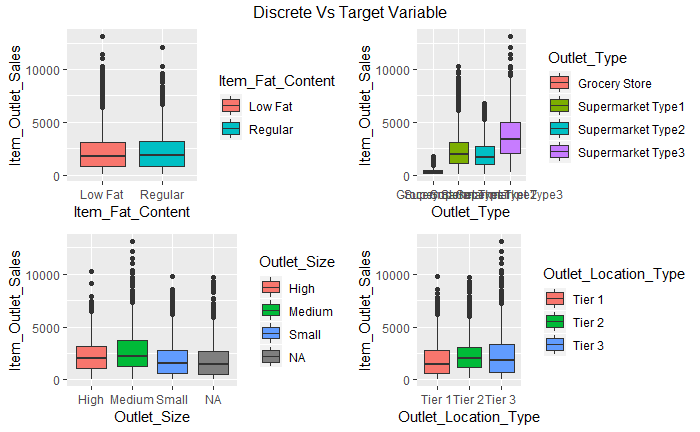

```r
# Discrete Vs Target Variable
p21 <- ggplot(Train,aes(Item_Fat_Content,Item_Outlet_Sales, fill = Item_Fat_Content)) + geom_boxplot()
p23 <- ggplot(Train,aes(Outlet_Size, Item_Outlet_Sales, fill = Outlet_Size)) +
        geom_boxplot()
p24 <- ggplot(Train,aes(Outlet_Location_Type, Item_Outlet_Sales, fill = Outlet_Location_Type)) +
        geom_boxplot()
p25 <- ggplot(Train,aes(Outlet_Type, Item_Outlet_Sales, fill = Outlet_Type)) +
        geom_boxplot()
grid.arrange(
  p21,p25,p23,p24, nrow = 2,
  top = "Discrete Vs Target Variable")
```

- Extreme values are encounted in all Box Plots

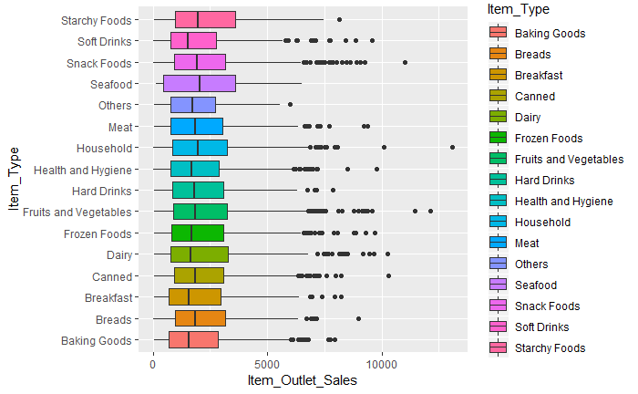

```r
ggplot(Train,aes(Item_Type,Item_Outlet_Sales, fill = Item_Type)) +
  geom_boxplot() + coord_flip()
```

- As in the above BOX Plots we can see that there are many Extreme Values, therefore we have treat them later.

## **Data Preprocessing**

### Missing Value Treatment

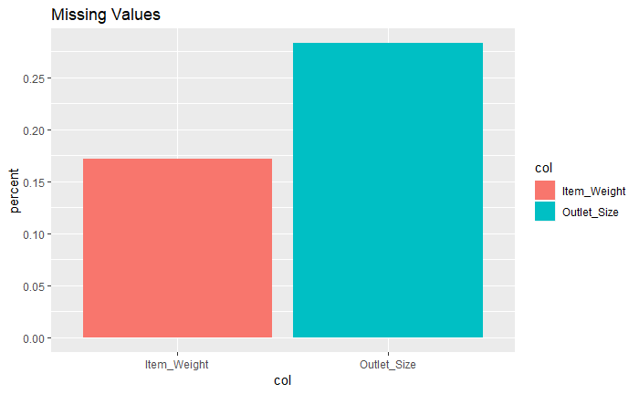

```r
# Getting missing value percentage
missing_val <- as.data.frame(sapply(All[,-c(12)], function(x) sum(is.na(x))/nrow(All[,-c(12)]) ))
# Renaming Column
colnames(missing_val) <- c("percent")
missing_val$col <-as.factor(row.names(missing_val))
missing_val <- filter( missing_val, percent > 0.0)
ggplot(missing_val, aes(y = percent,x = col, fill = col)) +
  geom_bar(stat = "identity") + scale_y_continuous(breaks = seq(0,1, by =0.05)) +   ggtitle("Missing Values")
```

```r
# Since there are more than 28% missing values in Outlet Size, therefore Dropping it.
All <- All[,-9]
# Replace Missing vaues in Item_Weight in mean
All = All %>% mutate_at(vars(Item_Weight),~ifelse(is.na(.x), mean(.x, na.rm = TRUE), .x))
# Total missing Values
sum(is.na(All[,-c(11)]))
```

```
[1] 0
```

### Replacing 0’s in Item_Visibility variable

As there can be no variable whose **Visibility** could be zero. Therefore imputing it with mean.

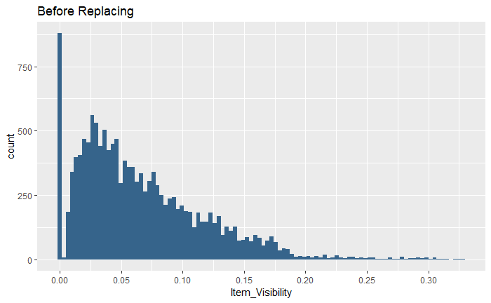

```r
# Since no item product can have zero visibility
ggplot(All, aes(Item_Visibility)) +
  geom_histogram( fill = "steelblue4", bins = 100)+
  scale_x_continuous(breaks = seq(0,0.5, by =0.05)) + ggtitle("Before Replacing")
```

```r
## Replace 0 in Item_Visibility by Mean
# Count no of zeros
All %>% filter( Item_Visibility == 0.0 ) %>% count(n())
```

| n() | n |
| --- | --- |
| 879 | 879 |

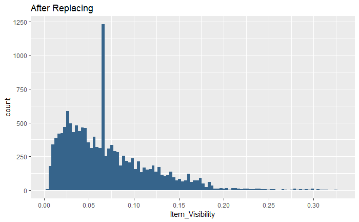

```r
# Replace with mean
All = All %>% mutate(Item_Visibility = replace(Item_Visibility,
                                                   which( Item_Visibility == 0.0),
                                                   mean(Train$Item_Visibility)))
ggplot(All, aes(Item_Visibility)) +
  geom_histogram( fill = "steelblue4", , bins = 100)+
  scale_x_continuous(breaks = seq(0,0.5, by =0.05))+ ggtitle("After Replacing")
```

## Feature Engineering

**Adding NEW Features** 1) * Convering **Outlet_Establishment_Year** into Outlet Working Years

```r
# Get unique years
  sort(unique(All$Outlet_Establishment_Year))
```

```
[1] 1985 1987 1997 1998 1999 2002 2004 2007 2009
```

```r
  ## Replace year with corresponding number
  All$Outlet_Establishment_Year[All$Outlet_Establishment_Year == 1985]<- 2018-1985
  All$Outlet_Establishment_Year[All$Outlet_Establishment_Year == 1987]<- 2018-1987
  All$Outlet_Establishment_Year[All$Outlet_Establishment_Year == 1997]<- 2018-1997
  All$Outlet_Establishment_Year[All$Outlet_Establishment_Year == 1998]<- 2018-1998
  All$Outlet_Establishment_Year[All$Outlet_Establishment_Year == 1999]<- 2018-1999
  All$Outlet_Establishment_Year[All$Outlet_Establishment_Year == 2002]<- 2018-2002
  All$Outlet_Establishment_Year[All$Outlet_Establishment_Year == 2004]<- 2018-2004
  All$Outlet_Establishment_Year[All$Outlet_Establishment_Year == 2007]<- 2018-2007
  All$Outlet_Establishment_Year[All$Outlet_Establishment_Year == 2009]<- 2018-2009
```

- Converiting **Item_MRP** into categories

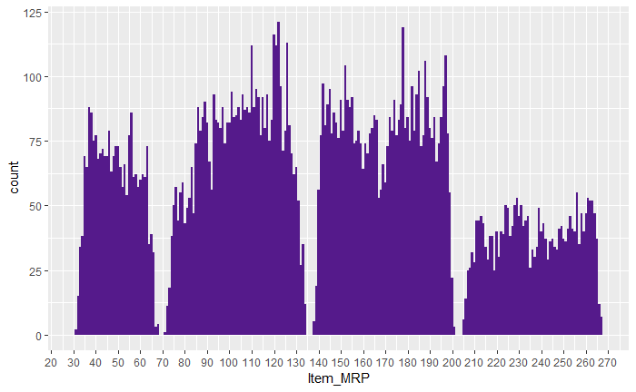

```r
ggplot(All, aes(Item_MRP)) +
      geom_histogram( fill = "purple4", na.rm = TRUE,binwidth = 1)+
      scale_x_continuous(breaks = seq(0,300, by =10))
```

```r
# Gap 1
All %>% select(Item_MRP) %>% filter(Item_MRP >68 & Item_MRP < 71 )
```

| Item_MRP |
| --- |

```r
# Gap 2
All %>% select(Item_MRP) %>% filter(Item_MRP >135 & Item_MRP < 137 )
```

| Item_MRP |
| --- |

```r
# Gap 3
All %>% select(Item_MRP) %>% filter(Item_MRP >202 & Item_MRP < 204 )
```

| Item_MRP |
| --- |

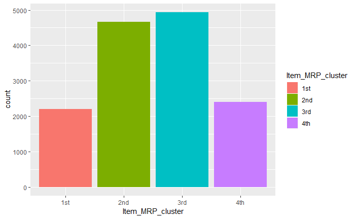

```r
# Creating new Column
All = All %>% mutate(Item_MRP_cluster = ifelse(Item_MRP < 69, "1st",      ifelse(Item_MRP >= 69 & Item_MRP < 136, "2nd",                              ifelse(Item_MRP >= 136 & Item_MRP < 203, "3rd", "4th"))))
# Converting into factors
All$Item_MRP_cluster<-as.factor(All$Item_MRP_cluster)
# Ploting
ggplot(All,aes(Item_MRP_cluster, fill = Item_MRP_cluster)) +
  geom_bar()
```

- Creating new Feature from **Item_Identifier**

As we know that in out dataset, * **DR** –> Drinks * **FD** –> Food * **NC** –> Non Consumable

```r
library(stringr)
All = All %>% mutate( Item_Category = str_sub(Item_Identifier,start = 1, end =2 ))
# Replacing Values
All$Item_Category[All$Item_Category == "DR"] <- "Drinks"
All$Item_Category[All$Item_Category == "FD"] <- "Foods"
All$Item_Category[All$Item_Category == "NC"] <- "Non Consumable"
# Converting into Factors
All$Item_Category <- as.factor(All$Item_Category)
levels(All$Item_Category)
```

```
[1] "Drinks"         "Foods"          "Non Consumable"
```

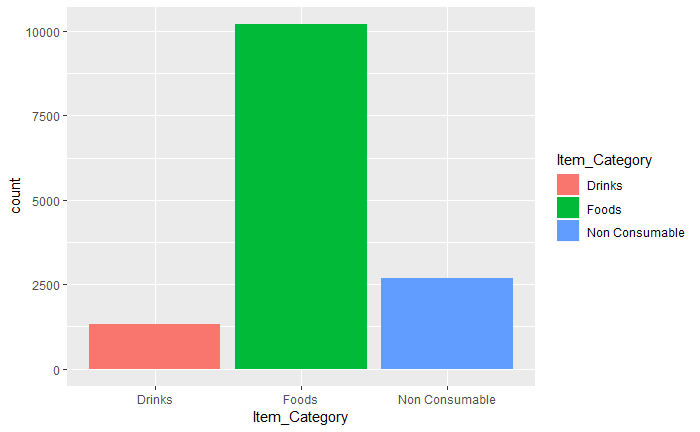

```r
# Ploting
ggplot(All,aes(Item_Category, fill = Item_Category)) +
  geom_bar()
```

- Creating new Feature from **Outlet_Identifier**

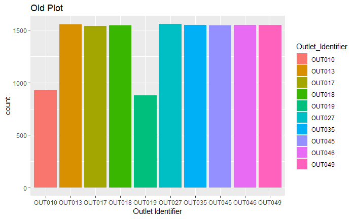

```r
# Ploting
ggplot(All,aes(as.factor(Outlet_Identifier), fill = Outlet_Identifier)) +
    geom_bar() + xlab("Outlet Identifier") + ggtitle("Old Plot")
```

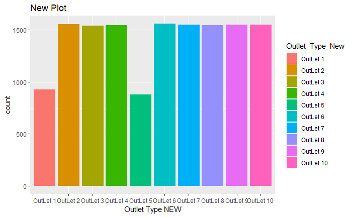

```r
# Creating new Column
All$Outlet_Type_New <- as.factor(All$Outlet_Identifier)
# Renaming Levels
levels(All$Outlet_Type_New) <- c("OutLet 1","OutLet 2","OutLet 3","OutLet 4","OutLet 5","OutLet 6","OutLet 7","OutLet 8","OutLet 9","OutLet 10")
# Drop Outlet Identifier
All <- All[,-c(7)]
# new Ploting
ggplot(All,aes(as.factor(Outlet_Type_New), fill = Outlet_Type_New)) + geom_bar() + xlab("Outlet Type NEW") + ggtitle("New Plot")
```

- Creating new Feature from **Item_MRP and Item_Weight**

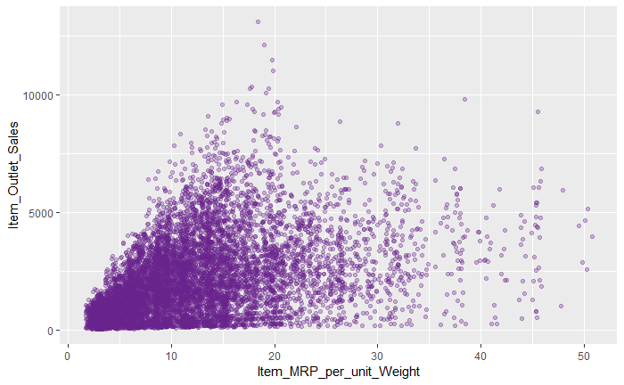

```r
All = All %>% mutate( Item_MRP_per_unit_Weight = All$Item_MRP/All$Item_Weight)
# Ploting
ggplot(All, aes(Item_MRP_per_unit_Weight,Item_Outlet_Sales))+
        geom_point(colour = 'darkorchid4',alpha=0.3)
```

6. Trying to combine Item_Type(16 levels) into smaller Types

```r
# Creating Table
kable(table(All$Item_Type,All$Item_Category), caption = "Tabel 1")
```

|  | Drinks | Foods | Non Consumable |
| --- | --- | --- | --- |
| Baking Goods | 0 | 1086 | 0 |
| Breads | 0 | 416 | 0 |
| Breakfast | 0 | 186 | 0 |
| Canned | 0 | 1084 | 0 |
| Dairy | 229 | 907 | 0 |
| Frozen Foods | 0 | 1426 | 0 |
| Fruits and Vegetables | 0 | 2013 | 0 |
| Hard Drinks | 362 | 0 | 0 |
| Health and Hygiene | 0 | 0 | 858 |
| Household | 0 | 0 | 1548 |
| Meat | 0 | 736 | 0 |
| Others | 0 | 0 | 280 |
| Seafood | 0 | 89 | 0 |
| Snack Foods | 0 | 1989 | 0 |
| Soft Drinks | 726 | 0 | 0 |
| Starchy Foods | 0 | 269 | 0 |

```r
kable(table(All$Item_Type,All$Item_Fat_Content), caption = "Tabel 2")
```

|  | Low Fat | Regular |
| --- | --- | --- |
| Baking Goods | 542 | 544 |
| Breads | 222 | 194 |
| Breakfast | 66 | 120 |
| Canned | 549 | 535 |
| Dairy | 691 | 445 |
| Frozen Foods | 731 | 695 |
| Fruits and Vegetables | 1086 | 927 |
| Hard Drinks | 362 | 0 |
| Health and Hygiene | 858 | 0 |
| Household | 1548 | 0 |
| Meat | 282 | 454 |
| Others | 280 | 0 |
| Seafood | 53 | 36 |
| Snack Foods | 1141 | 848 |
| Soft Drinks | 617 | 109 |
| Starchy Foods | 157 | 112 |

```r
perishable = c("Breads", "Breakfast", "Dairy", "Fruits and Vegetables", "Meat", "Seafood")
non_perishable = c("Baking Goods", "Canned", "Frozen Foods", "Hard Drinks", "Health and Hygiene", "Household", "Soft Drinks")
# create a new feature 'Item_Type_new'
All <- All %>% mutate(Item_Type_New = ifelse(Item_Type %in% perishable, "perishable", ifelse(Item_Type %in% non_perishable, "non_perishable", "not_sure")))
All$Item_Type_New <- as.factor(All$Item_Type_New)
# Dropping Item Type
All <- All[,-c(5)]
```

```r
#str(All )
All$Outlet_Location_Type <- as.factor(All$Outlet_Location_Type)
All$Outlet_Type <- as.factor(All$Outlet_Type)
```

### Removing Skewness

Checking Skewness of Continuous Variables

```r
library(moments)
cat("Skewness of Item_Weight is :",skewness(All$Item_Weight),
    "Skewness of Item_Visibility is :",skewness(All$Item_Visibility),
    "Skewness of Item_MRP is :",skewness(All$Item_MRP),
    "Skewness of Item_MRP_per_unit_Weight is :",skewness(All$Item_MRP_per_unit_Weight),fill =2)
```

```
Skewness of Item_Weight is :
0.1113021
Skewness of Item_Visibility is :
1.319938
Skewness of Item_MRP is :
0.1307146
Skewness of Item_MRP_per_unit_Weight is :
1.343897
```

In the above giving Result, as we can see that **Item_Visibility**,and **Item_MRP_per_unit_Weight** are highly skewed.

```r
All$Item_Visibility <- All$Item_Visibility^(1/3)
All$Item_Weight <- sqrt(All$Item_Weight)
All$Item_MRP_per_unit_Weight <- All$Item_MRP_per_unit_Weight^(1/3)
```

Scaling Numeric Variables and Creating Dummy Variables

```r
# Other than numeric Variables
set_2 <- All[,-c(2,4,6,14)]
# standardizing the Variables
set_1 <- normalizeFeatures(All[,c(2,4,6,14)],method = "standardize")
# Combining Sets
All_trans <- bind_cols( set_1, set_2)
# Creating Dummy Variable using MLR Pakage
All_trans <- createDummyFeatures(All_trans)
```

Splitting the combined data All back to train and test set.

```r
train <- All_trans[1:nrow(Train),]
test <- All_trans[(nrow(Train)+1):nrow(All_trans),]
# Removing Item_Outlet_Sales from test set
test <- test[, -c(8)]
```

### Correlation Between Variables

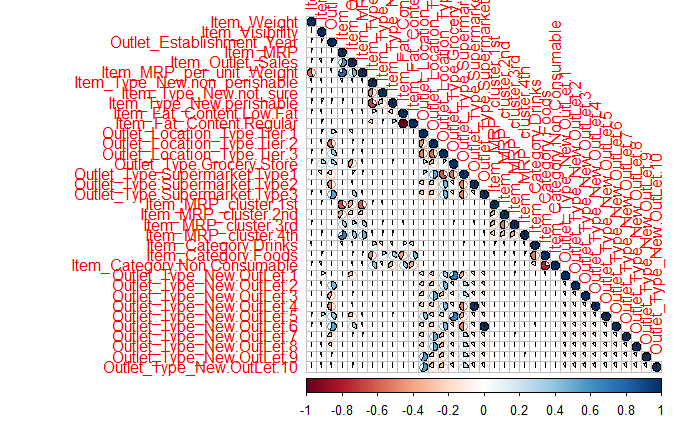

```r
# Making Correlation Matrix
library(corrplot)
cor_train = cor(train[,-c(4)])
corrplot(cor_train, method = "pie", type = "lower")
```

Obsevations * There are some highly correlated variables, therefore we have to remove them.

```r
# Converting into dataframe
cor_train <- as.data.frame(cor_train)
# making new columns from row names
cor_train <- cor_train %>% mutate( var_names = row.names(cor_train))
# filter having high correlation with Item Outlet Sales
kable(cor_train %>% select(var_names, Item_Outlet_Sales) %>% filter(Item_Outlet_Sales >0.3 | Item_Outlet_Sales < -0.3 ))
```

| var_names | Item_Outlet_Sales |
| --- | --- |
| Item_MRP | 0.5675744 |
| Item_Outlet_Sales | 1.0000000 |
| Item_MRP_per_unit_Weight | 0.4361606 |
| Outlet_Type.Grocery.Store | -0.4117271 |
| Outlet_Type.Supermarket.Type3 | 0.3111920 |
| Item_MRP_cluster.1st | -0.3658668 |
| Item_MRP_cluster.4th | 0.3944153 |
| Outlet_Type_New.OutLet.6 | 0.3111920 |

```r
# Dropping highly correlated variables from train set
train <- train[!(names(train)) %in% c('Outlet_Type_New.Outlet.4','Outlet_Type_New.Outlet.6','Outlet_Type_New.OutLet.5','Outlet_Type_New.OutLet.1','Item_Category.Non.Consumable','Item_MRP_cluster.4th','Item_Fat_Content.Low.Fat')]
# Dropping highly correlated variables from test set
test <- test[!(names(test)) %in% c('Outlet_Type_New.Outlet.4','Outlet_Type_New.Outlet.6','Outlet_Type_New.OutLet.5','Outlet_Type_New.OutLet.1','Item_Category.Non.Consumable','Item_MRP_cluster.4th','Item_Fat_Content.Low.Fat')]
```

### Split Train Dataset

```r
library(caTools)
set.seed(123)
split = sample.split(train$Item_Outlet_Sales, SplitRatio = 0.8)
train_set = subset(train[,-c(1)] , split==TRUE )
valid_set = subset(train[,-c(1)]  , split==FALSE )
```

### Model 1

```r
# Creating a task
ml_task <- makeRegrTask(data = train_set,target = 'Item_Outlet_Sales')
```

[output not shown]